# Decision Trees

Brian Chu

March 22, 2015

**1. Implement a function that takes a categorical vector (in character or factor form) and calculates the entropy for that vector. Your code should accept as input a single vector and output a single number.**

```r
entropy <- function(v) {
  v <- as.factor(v) #convert vector to factor
  v <- droplevels(v) #drop unused levels/responses (needed for some information gain calcs)
  tv <- table(v)
  pv <- prop.table(tv) #frequency of levels
  w <- numeric() #weight vector
  e <- numeric() #entropy vector
  for (i in 1:length(tv)) {
    w[i] <- tv[i] / length(v) #weight of level
    e[i] <- -w[i] * log2(w[i]) #entropy formula per level
  }
  entropy <- sum(e) #aggregate entropy value
  return(entropy)
}
```

Test with lens24 class vector (verify with texbook pg 57-58)

```r
url <- "http://archive.ics.uci.edu/ml/machine-learning-databases/lenses/lenses.data"
lens <- read.table(file=url)[,-1]
colnames(lens) <- c("age", "specRx", "astig", "tears", "class")
lens_class <- lens[,5]
f1 <- (entropy(lens_class)) #calculate entropy for age vector
f1
```

```
## [1] 1.326088
```

**2. Implement a function that calculates the information gain of one categorical vector when partitioned according to another categorical vector.**

```r
infgain <- function(v1, v2) {
  entropy_v1 <- entropy(v1) #calculate entropy for vector 1
  entropy_v2 <- entropy(v2) #calculate entropy for vector 2
  return(entropy_v1 - entropy_v2) #information gain = entropy difference
}
```

Test with lens24 age and specRx vectors

```r
age <- lens[,1]
specRx <- lens[,2]
f2 <- (infgain(age, specRx))
f2
```

```
## [1] 0.5849625
```

**3. Implement a function that takes as its input a data frame of categorical variables, one of which is identified as the target variable, and outputs the following in list format:**

- The information gain on the target column when partitioning according to each of the remaining columns
- The identity of the column that provides the highest information gain

```r
#returns list of information gain values
infogain_all <- function(df, target_col){
  df <- as.data.frame(lapply(df, as.factor)) #convert dataframe to factors
  target <- df[,target_col] #set target classification column
  x <- df[-target_col] #set input columns (i.e. everything except target)
  entropy_target <- entropy(target) #calculate entropy of target column (i.e. initial entropy)

  #initialize result list based on df column names
  num_cols <- ncol(x)
  name_list <- character(length=num_cols)
  for(i in 1:num_cols){
    name_list[i] <- colnames(x)[i]
  }
  result_list <- vector("list", length(name_list))
  names(result_list) <- name_list

  #PROCESS: loop over attributes, loop over factors, calc weighted entropy, calc information gain from target
  for(i in 1:num_cols) {
    entropy_vals <- numeric() #vector of entropy values per attribute
    attribute <- x[,i]
    n <- nlevels(attribute)
    p <- as.numeric(prop.table(table(attribute))) #weight of each factor level
    for(j in 1:n) {
      lev <- levels(attribute)[j]
      subtarget <- df[df[,i]==lev,target_col] #subset target based on factor level
      subtarget <- droplevels(subtarget) #drop unused levels
      entropy_vals[j] <- entropy(subtarget)
    }
    infogain <- entropy_target - sum(p*entropy_vals) #weighted average of attribute level
    result_list[i] <- infogain
  }

  return(result_list)
}

#returns max information gain attribute and value based on previous function
infogain_max <- function(l){
  igmax_id <- names(which.max(l)) #atribute name
  igmax_val <- round(max(unlist(l)), 4) #attribute value
  igmax <- (list("max"=igmax_id, "max_val"=igmax_val)) #convert to named list
  return(igmax)
}
```

Test using lens24 dataset (verify with textbook pg 60)

```r
lens_infogain <- infogain_all(lens, 5)
lens_igmax <- infogain_max(lens_infogain)
print(lens_infogain)
```

```
## $age
## [1] 0.0393965
##
## $specRx
## [1] 0.03951084
##
## $astig
## [1] 0.3770052
##
## $tears
## [1] 0.5487949
```

[output not shown]

**4. Using your custom functions above, build by hand a decision tree on the jury data contained in the file jury-training-data.csv. Document the final set of rules you come up with for the data set. (You should end up with a series of if/then statements, one for each final branch of your tree. Be sure to indicate the support and the probability at the end of each branch. You need not worry about a Laplace correction at this point.**

**Once you have built your decision tree, use it to classify all of the observations in the public and private testing data sets for the jury problem. Comment on how well your tree performs on the public data set. If you “prune your tree” can you get better results on the testing data? Explain.**

**For this task, you should submit:**

- Your set of decision rules
- The R code that you used to build the tree (this need not be polished, I just want to see how you made your tree)
- Your commentary on the classification success on the public learning data set
- Your classifications (as a CSV file or similar) of the private learning data set

```r
#inputs dataframe and target column number / outputs tree decision rules and classification probability
#I realize this algorithm would be better off in a function wrapper, but left this way to illustrate nested if/else pattern

decision_tree <- function(df, target_col) {
  df <- as.data.frame(lapply(df, as.factor)) #convert all columns to factors
  class_name <- colnames(df)[target_col]
  #check if all class instances are the same (i.e. no tree needed)
  if (nlevels(df[,target_col])==1){
    print(paste("all rows", "all levels", levels(df[,target_col])))
  }
  else{
    infogain1 <- infogain_all(df, target_col) #calculate infogain for all attributes
    attribute1 <- infogain_max(infogain1)[[1]] #select max infogain attribute to split on first
    n <- levels(df[,attribute1]) #count subset levels in attribute
    #check if all subsets return same class
    if (nlevels(df[,target_col])==1){
      print(paste(attribute1, "all levels", n))
    }
    else{
      for(i in n){ #loop over each subset level
        aclass <- df[df[,attribute1]==i, class_name] #class results for attribute subset
        aclass <- droplevels(aclass)
        if(nlevels(aclass)==1){ #if only one class, print class result
          print(paste(attribute1, i, levels(aclass)))
        }
        else{ #select next branch attribute
          attribute1id <- which(colnames(df)==attribute1)
          df2 <- df[df[,attribute1]==i,-c(attribute1id)] #filter out previous attribute from dataframe
          class_nameID <- which(colnames(df2)==class_name) #determine new target column id
          infogain2 <- infogain_all(df2, class_nameID) #determine next atrribute to filter on
          attribute2 <- infogain_max(infogain2)$max #attribute2 name
          n2 <- levels(df2[,attribute2]) #count attribute2 levels
          if (nlevels(df2[,class_nameID])==1){ #if only 1 level - print class result
            print(paste(attribute2, "all levels", n2))
          }

          #Repeat algorithm, looping through each attribute and factor level until only 1 class result remains
          #or all attributes are exhausted. Then determine classification based on the higher probability class
          #after the last attribute.

          else{
            for(i2 in n2){
              aclass2 <- df2[df2[,attribute2]==i2, class_name]
              aclass2 <- droplevels(aclass2)
              if(nlevels(aclass2)==1){
                print(paste(attribute1, i, attribute2, i2, levels(aclass2)))
              }
              else{
                attribute2id <- which(colnames(df2)==attribute2)
                df3 <- df2[df2[,attribute2]==i2,-c(attribute2id)]
                class_nameID <- which(colnames(df3)==class_name)
                infogain3 <- infogain_all(df3, class_nameID)
                attribute3 <- infogain_max(infogain3)$max
                n3 <- levels(df3[,attribute3])
                if (nlevels(df3[,class_nameID])==1){
                  print(paste(attribute3, "all levels", n3))
                }
                else{
                  for(i3 in n3){
                    aclass3 <- df3[df3[,attribute3]==i3, class_name]
                    aclass3 <- droplevels(aclass3)
                    if(nlevels(aclass3)==1){
                      print(paste(attribute1, i, attribute2, i2, attribute3, i3, levels(aclass3)))
                    }
                    else{
                      attribute3id <- which(colnames(df3)==attribute3)
                      df4 <- df3[df3[,attribute3]==i3,-c(attribute3id)]
                      class_nameID <- which(colnames(df4)==class_name)
                      infogain4 <- infogain_all(df4, class_nameID)
                      attribute4 <- infogain_max(infogain4)$max
                      n4 <- levels(df4[,attribute4])
                      if (nlevels(df4[,class_nameID])==1){
                        print(paste(attribute4, "all levels", n4))
                      }
                      else{
                        for(i4 in n4){
                          aclass4 <- df4[df4[,attribute4]==i4, class_name]
                          aclass4 <- droplevels(aclass4)
                          if(nlevels(aclass4)==1){
                            print(paste(attribute1, i, attribute2, i2, attribute3,
                                        i3, attribute4, i4, levels(aclass4)))
                          }
                          else{
                            #no more attributes to split on.
                            #determine class by higher probability of remaining factors
                            max_proportion <- names(sort((table(aclass4)), decreasing=TRUE)[1])
                            max_proportion_value <- round(max(prop.table(table(aclass4))), 4)
                            print(paste(attribute1, i, attribute2, i2, attribute3, i3, attribute4, i4,
                                        max_proportion, max_proportion_value))
                          }
                        }
                      }
                    }
                  }
                }
              }
            }
          }
        }
      }
    }
  }
}
```

**Test on Jury Training data**

```r
juryTraining <- read.csv("jury-training-data.csv")
juryTraining <- juryTraining[complete.cases(juryTraining),]
decision_tree(juryTraining, 5)
```

```
## [1] "gender Female marital Divorced agegroup Older Adult employment Employed Guilty 0.8571"
## [1] "gender Female marital Divorced agegroup Older Adult employment Not Employed Guilty 0.8421"
## [1] "gender Female marital Divorced agegroup Younger Adult employment Employed Guilty 0.8421"
## [1] "gender Female marital Divorced agegroup Younger Adult employment Not Employed Guilty 0.8182"
## [1] "gender Female marital Married agegroup Older Adult employment Employed Not Guilty 0.6111"
## [1] "gender Female marital Married agegroup Older Adult employment Not Employed Not Guilty 0.9167"
## [1] "gender Female marital Married agegroup Younger Adult employment Employed Guilty 0.5625"
## [1] "gender Female marital Married agegroup Younger Adult employment Not Employed Guilty 0.5294"
## [1] "gender Female marital Single agegroup Older Adult employment Employed Guilty 0.8571"
## [1] "gender Female marital Single agegroup Older Adult employment Not Employed Guilty 0.8"
## [1] "gender Female marital Single agegroup Younger Adult employment Employed Guilty 0.7692"
## [1] "gender Female marital Single agegroup Younger Adult employment Not Employed Guilty 0.6154"
## [1] "gender Male marital Divorced employment Employed agegroup Older Adult Not Guilty 0.7857"
## [1] "gender Male marital Divorced employment Employed agegroup Younger Adult Not Guilty 0.7857"
## [1] "gender Male marital Divorced employment Not Employed agegroup Older Adult Not Guilty 0.6842"
## [1] "gender Male marital Divorced employment Not Employed agegroup Younger Adult Not Guilty 0.5333"
## [1] "gender Male marital Married employment Employed agegroup Older Adult Guilty 0.5455"
## [1] "gender Male marital Married employment Employed agegroup Younger Adult Guilty 0.8889"
## [1] "gender Male marital Married employment Not Employed agegroup Older Adult Guilty 0.5"
## [1] "gender Male marital Married employment Not Employed agegroup Younger Adult Not Guilty 0.6154"
## [1] "gender Male marital Single employment Employed agegroup Older Adult Not Guilty 0.7857"
## [1] "gender Male marital Single employment Employed agegroup Younger Adult Not Guilty 0.7143"
## [1] "gender Male marital Single employment Not Employed agegroup Older Adult Not Guilty 0.625"
## [1] "gender Male marital Single employment Not Employed agegroup Younger Adult Not Guilty 0.6667"
```

**Create Decision Tree Function for Jury Data**

```r
jury_tree <- function(v) {
  if (v$gender=="Female"){
    if (v$marital=="Divorced"){
      return("Guilty")
    }
    else if (v$marital=="Married"){
      if (v$agegroup=="Older Adult"){
        return("Not Guilty")
      }
      else if (v$agegroup=="Younger Adult"){
        return("Guilty")
      }
    }
    else if (v$marital=="Single"){
      return("Guilty")
    }
  }
  else if (v$gender=="Male") {
    if (v$marital=="Divorced") {
      return("Not Guilty")
    }
    else if (v$marital=="Married") {
      if (v$employment=="Employed") {
        return("Guilty")
      }
      else if (v$employment=="Not Employed") {
        if (v$agegroup=="Older Adult") {
          return("Guilty")
        }
        else if (v$agegroup=="Younger Adult") {
          return("Not Guilty")
        }
      }
    }
    else if (v$marital=="Single") {
      return("Not Guilty")
    }
  }
}
```

**Apply decision tree to classify public jury training set**

```r
juryPublic <- read.csv("jury-learning-data-public.csv")
juryPublic <- juryPublic[complete.cases(juryPublic),]
for (i in 1:nrow(juryPublic)) {
  juryPublic$class[i] <- jury_tree(juryPublic[i,])
}
head(juryPublic, 5)
```

```
##        agegroup   employment gender  marital   tendency      class
## 1   Older Adult     Employed   Male   Single Not Guilty Not Guilty
## 2   Older Adult Not Employed Female  Married Not Guilty Not Guilty
## 3   Older Adult Not Employed Female Divorced     Guilty     Guilty
## 5 Younger Adult Not Employed Female   Single     Guilty     Guilty
## 6   Older Adult Not Employed Female   Single     Guilty     Guilty
```

**Evaluate performance of decision tree**

```r
library(caret)
confusionMatrix(data=juryPublic$class, reference=juryPublic$tendency, positive="Guilty")
```

```
## Confusion Matrix and Statistics
##
##             Reference
## Prediction   Guilty Not Guilty
##   Guilty         45         29
##   Not Guilty      9         36
##
##                Accuracy : 0.6807
##                  95% CI : (0.589, 0.7631)
##     No Information Rate : 0.5462
##     P-Value [Acc > NIR] : 0.001925
##
##                   Kappa : 0.3754
##  Mcnemar's Test P-Value : 0.002055
##
##             Sensitivity : 0.8333
##             Specificity : 0.5538
##          Pos Pred Value : 0.6081
##          Neg Pred Value : 0.8000
##              Prevalence : 0.4538
##          Detection Rate : 0.3782
##    Detection Prevalence : 0.6218
##       Balanced Accuracy : 0.6936
##
##        'Positive' Class : Guilty
##
```

The decision tree correctly classified 68% of instances. This is decent but specificity is low (55%), meaning several innocent persons were classified as guilty. This is obviously not ideal and we can probably do better with other classification techniques or better tree strategy.

**Pruning**: Based on the decision tree above, it looks like a simplified algorithm could be made just looking at gender and marital status. Specifically, female-married are primarily Not Guilty while female-single/divorced are mostly Guilty. The opposite is true for males.

```r
jury_tree_prune <- function(v) {
  if (v$gender=="Female"){
    if (v$marital=="Married"){
      return("Not Guilty")
    }
    else {
      return("Guilty")
    }
  }
  else if (v$gender=="Male") {
    if (v$marital=="Married") {
      return("Guilty")
    }
    else {
      return("Not Guilty")
    }
  }
}

juryPublicPrune <- juryPublic
juryPublicPrune <- juryPublicPrune[complete.cases(juryPublicPrune),]
for (i in 1:nrow(juryPublicPrune)) {
  juryPublicPrune$class[i] <- jury_tree_prune(juryPublicPrune[i,])
}
confusionMatrix(data=juryPublicPrune$class, reference=juryPublic$tendency, positive="Guilty")
```

```
## Confusion Matrix and Statistics
##
##             Reference
## Prediction   Guilty Not Guilty
##   Guilty         47         21
##   Not Guilty      7         44
##
##                Accuracy : 0.7647
##                  95% CI : (0.6782, 0.8376)
##     No Information Rate : 0.5462
##     P-Value [Acc > NIR] : 6.534e-07
##
##                   Kappa : 0.5355
##  Mcnemar's Test P-Value : 0.01402
##
##             Sensitivity : 0.8704
##             Specificity : 0.6769
##          Pos Pred Value : 0.6912
##          Neg Pred Value : 0.8627
##              Prevalence : 0.4538
##          Detection Rate : 0.3950
##    Detection Prevalence : 0.5714
##       Balanced Accuracy : 0.7736
##
##        'Positive' Class : Guilty
##
```

**Classify private test set**

```r
juryPrivate <- read.csv("jury-learning-data-private.csv")
juryPrivate <- juryPrivate[complete.cases(juryPrivate),]
for (i in 1:nrow(juryPrivate)) {
  juryPrivate$class[i] <- jury_tree(juryPrivate[i,])
}

juryPrivatePrune <- juryPrivate
for (i in 1:nrow(juryPrivatePrune)) {
  juryPrivatePrune$class[i] <- jury_tree_prune(juryPrivatePrune[i,])
}

write.csv(juryPrivate, "bchu_juryPrivate.csv")
write.csv(juryPrivatePrune, "bchu_juryPrivatePrune.csv")
head(juryPrivate, 10)
```

```
##         agegroup   employment gender  marital      class
## 1    Older Adult     Employed   Male  Married     Guilty
## 2  Younger Adult Not Employed Female Divorced     Guilty
## 3  Younger Adult Not Employed   Male Divorced Not Guilty
## 4    Older Adult Not Employed Female  Married Not Guilty
## 5  Younger Adult Not Employed   Male  Married Not Guilty
## 6    Older Adult     Employed Female  Married Not Guilty
## 7    Older Adult     Employed   Male   Single Not Guilty
## 8  Younger Adult Not Employed Female   Single     Guilty
## 9  Younger Adult     Employed   Male  Married     Guilty
## 10 Younger Adult     Employed   Male   Single Not Guilty
```

See attached CSV files for full private data classification results  
* bchu_juryPrivate.csv  
* bchu_juryPrivatePrune.csv

**Try out rpart package**

```r
library(rpart)
fit <- rpart(tendency ~ agegroup + employment + marital + gender, data=juryTraining)
fit
```

```
## n= 359
##
## node), split, n, loss, yval, (yprob)
##       * denotes terminal node
##
##  1) root 359 168 Guilty (0.5320334 0.4679666)
##    2) gender=Female 188  61 Guilty (0.6755319 0.3244681)
##      4) marital=Divorced,Single 125  24 Guilty (0.8080000 0.1920000) *
##      5) marital=Married 63  26 Not Guilty (0.4126984 0.5873016)
##       10) agegroup=Younger Adult 33  15 Guilty (0.5454545 0.4545455) *
##       11) agegroup=Older Adult 30   8 Not Guilty (0.2666667 0.7333333) *
##    3) gender=Male 171  64 Not Guilty (0.3742690 0.6257310)
##      6) marital=Married 47  21 Guilty (0.5531915 0.4468085)
##       12) employment=Employed 20   6 Guilty (0.7000000 0.3000000) *
##       13) employment=Not Employed 27  12 Not Guilty (0.4444444 0.5555556) *
##      7) marital=Divorced,Single 124  38 Not Guilty (0.3064516 0.6935484) *
```

These are practically the same decision rules as the manual decision tree algorithm. Visualize tree below.

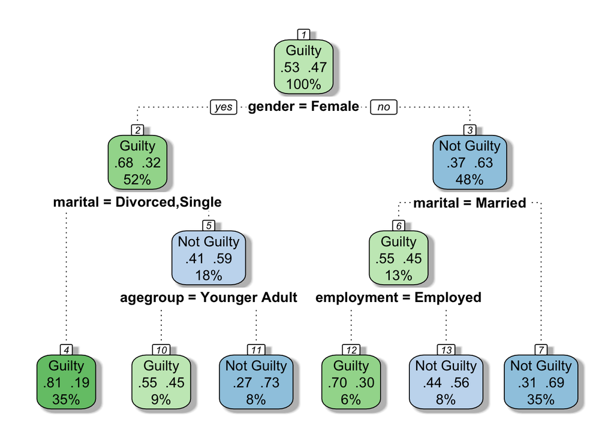

```r
library(rattle)
library(rpart.plot)
fancyRpartPlot(fit, sub="")
```

**Evaluate rpart classification accurary with Jury Public set**

```r
rpart_predict <- predict(fit, juryPublic[,-5], type="class")
confusionMatrix(data=rpart_predict, reference=juryPublic$tendency, positive="Guilty")
```

```
## Confusion Matrix and Statistics
##
##             Reference
## Prediction   Guilty Not Guilty
##   Guilty         42         28
##   Not Guilty     12         37
##
##                Accuracy : 0.6639
##                  95% CI : (0.5715, 0.7478)
##     No Information Rate : 0.5462
##     P-Value [Acc > NIR] : 0.006031
##
##                   Kappa : 0.3385
##  Mcnemar's Test P-Value : 0.017706
##
##             Sensitivity : 0.7778
##             Specificity : 0.5692
##          Pos Pred Value : 0.6000
##          Neg Pred Value : 0.7551
##              Prevalence : 0.4538
##          Detection Rate : 0.3529
##    Detection Prevalence : 0.5882
##       Balanced Accuracy : 0.6735
##
##        'Positive' Class : Guilty
##
```

Results are more or less the same as my manual decision tree algorithm but less than the pruned tree.

**Try out C50 package**

```r
library(C50)
juryTrainX <- juryTraining[,1:4]
juryTrainY <- juryTraining[,5]
juryTrain_c50 <- C5.0(juryTrainX, juryTrainY)
summary(juryTrain_c50)
```

```
##
## Call:
## C5.0.default(x = juryTrainX, y = juryTrainY)
##
##
## C5.0 [Release 2.07 GPL Edition]      Tue Mar 24 00:32:26 2015
## -------------------------------
##
## Class specified by attribute `outcome'
##
## Read 359 cases (5 attributes) from undefined.data
##
## Decision tree:
##
## gender = Female:
## :...marital in {Divorced,Single}: Guilty (125/24)
## :   marital = Married: Not Guilty (63/26)
## gender = Male:
## :...marital in {Divorced,Single}: Not Guilty (124/38)
##     marital = Married: Guilty (47/21)
##
##
## Evaluation on training data (359 cases):
##
##      Decision Tree
##    ----------------
##    Size      Errors
##
##       4  109(30.4%)   <<
##
##
##     (a)   (b)    <-classified as
##    ----  ----
##     127    64    (a): class Guilty
##      45   123    (b): class Not Guilty
##
##
##  Attribute usage:
##
##  100.00% gender
##  100.00% marital
##
##
## Time: 0.0 secs
```

**Results on public jury set**

```r
juryPublicX <- juryPublic[,1:4]
c50_predict <- predict(juryTrain_c50, juryPublicX, type="class")
confusionMatrix(data=c50_predict, reference=juryPublic$tendency, positive="Guilty")
```

```
## Confusion Matrix and Statistics
##
##             Reference
## Prediction   Guilty Not Guilty
##   Guilty         47         21
##   Not Guilty      7         44
##
##                Accuracy : 0.7647
##                  95% CI : (0.6782, 0.8376)
##     No Information Rate : 0.5462
##     P-Value [Acc > NIR] : 6.534e-07
##
##                   Kappa : 0.5355
##  Mcnemar's Test P-Value : 0.01402
##
##             Sensitivity : 0.8704
##             Specificity : 0.6769
##          Pos Pred Value : 0.6912
##          Neg Pred Value : 0.8627
##              Prevalence : 0.4538
##          Detection Rate : 0.3950
##    Detection Prevalence : 0.5714
##       Balanced Accuracy : 0.7736
##
##        'Positive' Class : Guilty
##
```

These classification results are equivalent to my pruned decision tree algorithm results!